# ISLR - Chapter 3 Linear Regression: Applied Q8,Q9: SLR & MLR

Chee Loong Lian

12/7/2017

**Data Explanation**

Origin: The dataset was used in the 1983 American Statistical Association Exposition.

Description: Gas mileage, horsepower, and other information for 392 vehicles.

Format: A data frame with 392 observations on the following 9 variables.

1. *mpg: miles per gallon*
2. *cylinders: Number of cylinders between 4 and 8*
3. *displacement: Engine displacement (cu. inches)*
4. *horsepower: Engine horsepower*
5. *weight: Vehicle weight (lbs.)*
6. *acceleration: Time to accelerate from 0 to 60 mph (sec.)*
7. *year: Model year (modulo 100)*
8. *origin: Origin of car (1. American, 2. European, 3. Japanese)*
9. *name: Vehicle name*

**Q8(a) Simple Linear Regression on the “Auto” data set**

```r
library(MASS); library(ISLR)
head(Auto)
```

```
##   mpg cylinders displacement horsepower weight acceleration year origin
## 1  18         8          307        130   3504         12.0   70      1
## 2  15         8          350        165   3693         11.5   70      1
## 3  18         8          318        150   3436         11.0   70      1
## 4  16         8          304        150   3433         12.0   70      1
## 5  17         8          302        140   3449         10.5   70      1
## 6  15         8          429        198   4341         10.0   70      1
##                        name
## 1 chevrolet chevelle malibu
## 2         buick skylark 320
## 3        plymouth satellite
## 4             amc rebel sst
## 5               ford torino
## 6          ford galaxie 500
```

```r
attach(Auto)
```

**(i) Is there a relationship between the predictor and the response?**

```r
lm.fit <- lm(mpg ~ horsepower, data = Auto)
summary(lm.fit)
```

```
##
## Call:
## lm(formula = mpg ~ horsepower, data = Auto)
##
## Residuals:
##      Min       1Q   Median       3Q      Max
## -13.5710  -3.2592  -0.3435   2.7630  16.9240
##
## Coefficients:
##              Estimate Std. Error t value Pr(>|t|)
## (Intercept) 39.935861   0.717499   55.66   <2e-16 ***
## horsepower  -0.157845   0.006446  -24.49   <2e-16 ***
## ---
## Signif. codes:  0 '***' 0.001 '**' 0.01 '*' 0.05 '.' 0.1 ' ' 1
##
## Residual standard error: 4.906 on 390 degrees of freedom
## Multiple R-squared:  0.6059, Adjusted R-squared:  0.6049
## F-statistic: 599.7 on 1 and 390 DF,  p-value: < 2.2e-16
```

Yes, there is a relationship between horsepower and mpg as determined by testing the null hypothesis of all regression coefficients equal to zero. Since the F-statistic (599.7) is far larger than 1 and the p-value (2.2e-16) of the F-statistic is close to zero we can reject the null hypothesis and state there is a statistically significant relationship between horsepower and mpg.

**(ii) How strong is the relationship between the predictor and the response ?**

```r
mean(mpg)
```

```
## [1] 23.44592
```

```r
(4.906/23.446)*100
```

```
## [1] 20.92468
```

To calculate the residual error relative to the response we use the mean of the response and the RSE. The mean of mpg is 23.4459. The RSE of the lm.fit was 4.906 which indicates a percentage error of 20.9248%. The R-squared of the lm.fit was about 0.6059, meaning 60.5948% of the variance in mpg is explained by horsepower.

**(iii) Is the relationship between the predictor and the response positive or negative ?**

The relationship between mpg and horsepower is negative. The more horsepower an automobile has the linear regression indicates the less mpg fuel efficiency the automobile will have.

**(iv) What is the predicted mpg associated with a “horsepower” of 98 ? What are the associated 95% confidence and prediction intervals ?**

```r
predict(lm.fit, data.frame(horsepower = 98), interval = "confidence")
```

```
##        fit      lwr      upr
## 1 24.46708 23.97308 24.96108
```

```r
predict(lm.fit, data.frame(horsepower = 98), interval = "prediction")
```

```
##        fit     lwr      upr
## 1 24.46708 14.8094 34.12476
```

The predicted mpg associated with a “horsepower” of 98 is about 24.47.

We are 95% confident that the average mpg of a car with horsepower of 98 is between 23.97 to 24.96.

We are 95% confident that the mpg of a car with horsepower of 98 is between 14.81 to 34.12.

**Q8(b) Plot the response and the predictor, display the least squares regression line.**

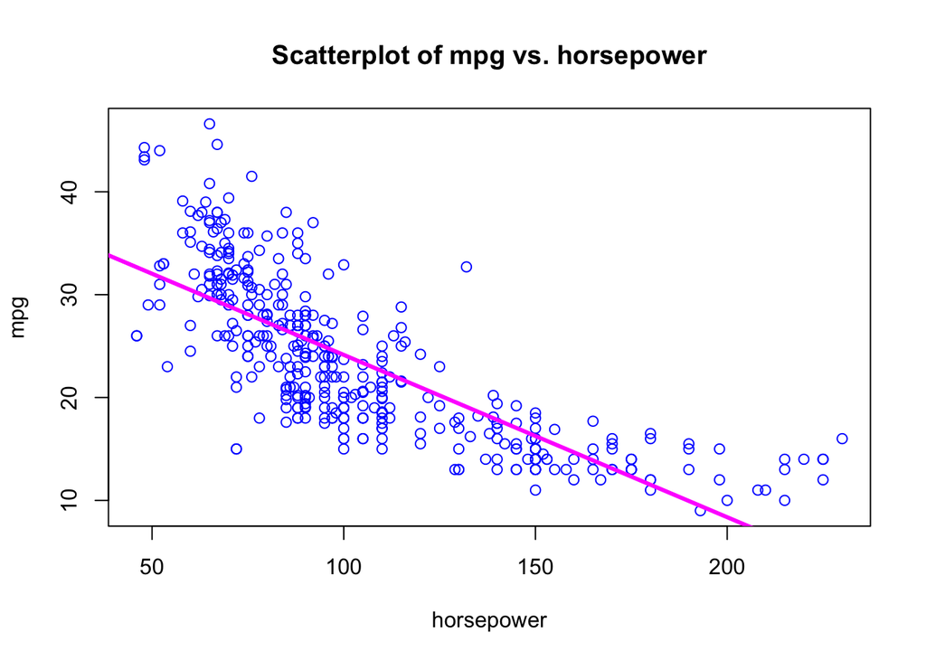

```r
plot(horsepower, mpg, main = "Scatterplot of mpg vs. horsepower", xlab = "horsepower", ylab = "mpg", col = "blue")
abline(lm.fit, lwd = 3, col = "magenta")
```

**Q8(c) Produce diagnostic plots of the least squares regression fit. Comment.**

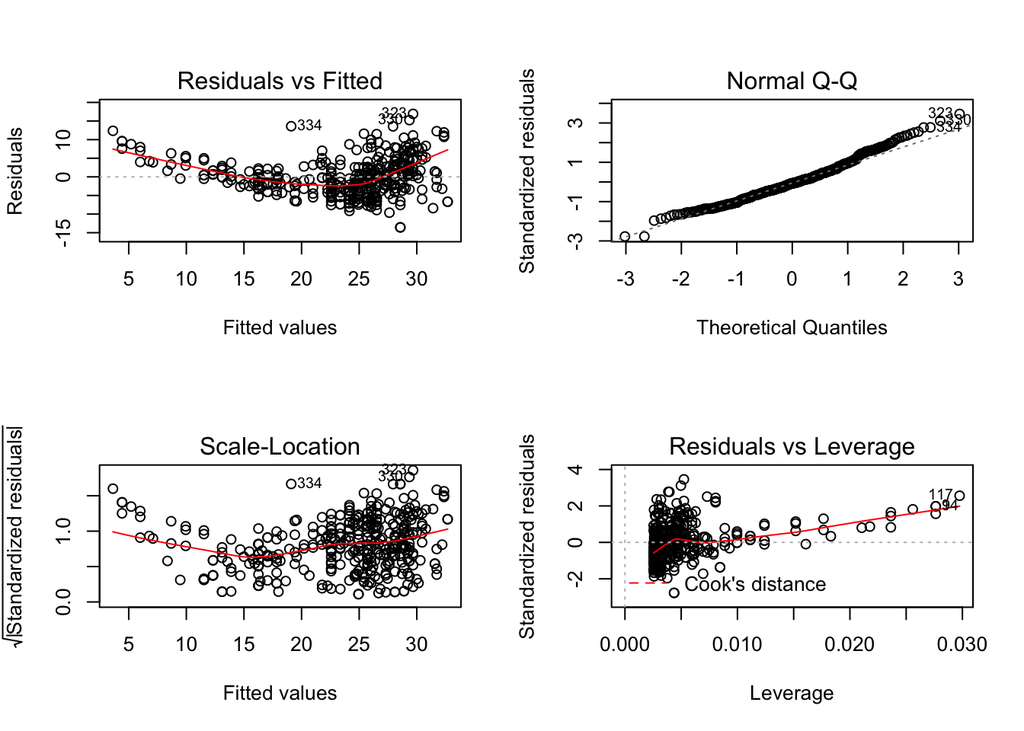

```r
par(mfrow = c(2,2))
plot(lm.fit)
```

The plot of residuals versus fitted values indicates the presence of non linearity in the data. The plot of standardized residuals versus leverage indicates the presence of a few outliers (higher than 2 or lower than -2) and a few high leverage points.